# Genome-wide DNA binding in HEPG2

JR

4/17/2022

# Goal:

Here we aim to download all available DNA binding protein (DBP) profiles in a single cell state (measured by ChIP-seq) . This will allow us to investigate the binding properties of hundreds of DBPs in the same cellular context or background. We aim to address several questions: (i) What are the number of peaks and genome coverage for each DBP? (ii) What are the binding preferences for promoters, gene-bodies and intergenic genomic regions? (iii) What are the similarities and differences across DBPs based on their genome-wide binding profiles genome-wide? (iv) What properties or preferences do promoters have for binding events. (iv) Are there reservoir promoters in HepG2 as defined in k562 previously? (v) How does binding to a promoter affect the transcriptional output of that promoter?

https://www.encodeproject.org/report/?type=Experiment&status=released&assay_slims=DNA+binding&biosample_ontology.term_name=HepG2&assay_title=TF+ChIP-seq&biosample_ontology.classification=cell+line&files.read_length=100&files.read_length=76&files.read_length=75&files.read_length=36&assay_title=Control+ChIP-seq&assay_title=Histone+ChIP-seq&files.run_type=single-ended

## These samples were selected on the following criteria:

1. “chromatin” interaction data, then DNA binding data, cell line HEPG2, “TF-Chip-seq”.
2. We further selected “TF Chip-seq”, “Control chip-seq” and “Histone Chip-seq”.
3. We selected several read lengths to get the most DNA binding proteins (DBPs)
4. Read lengths: 100, 76, 75, 36
5. ONLY SINGLE END READS (this eliminates 54 samples)

### Experimental data was downloading by (ENCODE report.tsv):

https://www.encodeproject.org/report.tsv?type=Experiment&status=released&assay_slims=DNA+binding&biosample_ontology.term_name=HepG2&assay_title=TF+ChIP-seq&biosample_ontology.classification=cell+line&files.read_length=100&files.read_length=76&files.read_length=75&files.read_length=36&assay_title=Control+ChIP-seq&assay_title=Histone+ChIP-seq&files.run_type=single-ended

### The FASTQ files were downloaded with:

“https://www.encodeproject.org/metadata/?status=released&assay_slims=DNA+binding&biosample_ontology.term_name=HepG2&assay_title=TF+ChIP-seq&biosample_ontology.classification=cell+line&files.read_length=100&files.read_length=76&files.read_length=75&files.read_length=36&assay_title=Control+ChIP-seq&assay_title=Histone+ChIP-seq&files.run_type=single-ended&type=Experiment”

MD5sums were checked with all passing (see encode_file_info function to reterive MD5Sum values that are not available from the encode portal (/util)

### Processing data:

We processed all the read alignments and peak calling using the NF_CORE ChIP-seq pipeline: (nfcore/chipseq v1.2.1)

## Next we created consensus peaks that overlap in both replicates

Our strategy was to take peaks in each replicate and find all overlapping peak windows. We then took the union length of the overlapping range in each peak window.

```r
# create_consensus_peaks requires an annotation .GTF file - loading in Gencode v32 annotations.
gencode_gr <- rtracklayer::import("/scratch/Shares/rinnclass/CLASS_2022/data/genomes/gencode.v32.annotation.gtf")

# Creating consensus peaks function to create a .bed file of overlapping peaks in each replicate.
# /util/intersect_functions.R

# TODO run this only on final knit
# create_consensus_peaks <- create_consensus_peaks(broadpeakfilepath = "/scratch/Shares/rinnclass/CLASS_2022/data/test_work/all_peak_files")

# exporting consensus peaks .bed files

# TODO run this only on final knit
# for(i in 1:length(consensus_peaks)) {
#  rtracklayer::export(consensus_peaks[[i]],
#                     paste0("/scratch/Shares/rinnclass/CLASS_2022/JR/CLASS_2022/class_exeRcises/analysis/11_consensus_peaks/consensus_peaks/",
#                             names(consensus_peaks)[i],
#                             "_consensus_peaks.bed"))
# }
```

# loading in consensus peaks to prevent rerunning create_consensus_peaks function

```r
# Loading in files via listing and rtracklayer import
consensus_fl <- list.files("/scratch/Shares/rinnclass/CLASS_2022/JR/CLASS_2022/class_exeRcises/analysis/11_consensus_peaks/consensus_peaks", full.names = T)

# importing (takes ~5min)
consensus_peaks <- lapply(consensus_fl, rtracklayer::import)

# cleaning up file names
names(consensus_peaks) <- gsub("/scratch/Shares/rinnclass/CLASS_2022/JR/CLASS_2022/class_exeRcises/analysis/11_consensus_peaks/consensus_peaks/|_consensus_peaks.bed","", consensus_fl)

# Filtering consensus peaks to those DBPs with at least 250 peaks
num_peaks_threshold <- 250
num_peaks <- sapply(consensus_peaks, length)
filtered_consensus_peaks <- consensus_peaks[num_peaks > num_peaks_threshold]

# Result: these were the DBPs that were filtered out.
filtered_dbps <- consensus_peaks[num_peaks < num_peaks_threshold]
names(filtered_dbps)
```

```
##  [1] "CEBPZ"    "GPBP1L1"  "H3K27me3" "HMGA1"    "IRF3"     "MLLT10"
##  [7] "MYBL2"    "NCOA5"    "RNF219"   "RORA"     "ZBTB3"    "ZFP36"
## [13] "ZFP62"    "ZMAT5"    "ZNF10"    "ZNF17"    "ZNF260"   "ZNF382"
## [19] "ZNF48"    "ZNF484"   "ZNF577"   "ZNF597"   "ZNF7"
```

```r
# We have this many remaining DBPs
length(filtered_consensus_peaks)
```

```
## [1] 460
```

## Now we will determine the peak number and genome coverage for each DBP.

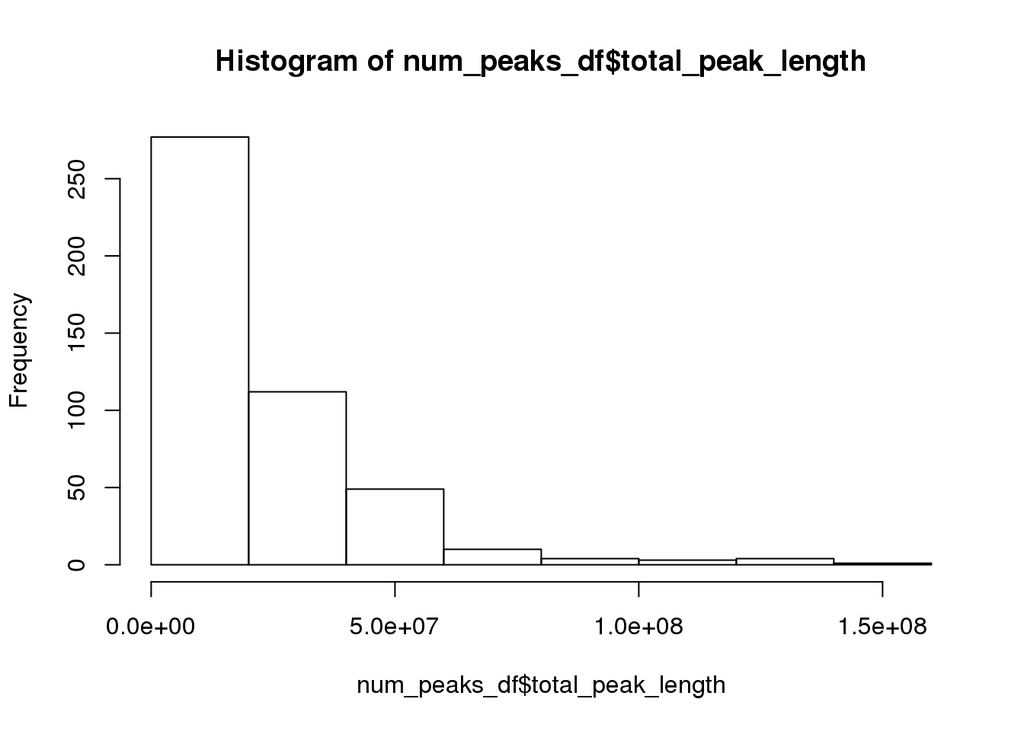

```r
# Let's start with loading in the number of peaks each DBP has -- using length.
num_peaks_df <- data.frame("dbp" = names(filtered_consensus_peaks),
                           "num_peaks" = sapply(filtered_consensus_peaks, length))

# total genomic coverage of peaks for each dbp
num_peaks_df$total_peak_length <- sapply(filtered_consensus_peaks, function(x) sum(width(x)))

# Plotting distribution of peak number per dbp
hist(num_peaks_df$total_peak_length)
```

# Now we will create promoter annotations for lncRNA and mRNA and both.

We have created a funciton get_promter_regions that has up and downstream parameters

```r
# creating lncRNA and mRNA promoters
lncrna_mrna_promoters <- get_promoter_regions(gencode_gr, biotype = c("lncRNA", "protein_coding", upstream = 1500, downstream = 1500))
names(lncrna_mrna_promoters) <- lncrna_mrna_promoters$gene_id
rtracklayer::export(lncrna_mrna_promoters, "analysis/results/lncRNA_mrna_promoters.gtf")

# creating lncRNAs promoter
lncrna_promoters <- get_promoter_regions(gencode_gr, biotype = "lncRNA", upstream = 1500, downstream = 1500)
names(lncrna_promoters) <- lncrna_promoters$gene_id
rtracklayer::export(lncrna_promoters, "analysis/results/lncRNA_promoters.gtf")

# creating mRNA promoters
mrna_promoters <- get_promoter_regions(gencode_gr, biotype = "protein_coding", upstream = 1500, downstream = 1500)
names(mrna_promoters) <- mrna_promoters$gene_id
rtracklayer::export(lncrna_promoters, "analysis/results/mRNA_promoters.gtf")

# creating all genebody annotation
lncrna_mrna_genebody <- gencode_gr[gencode_gr$type == "gene" &
                                     gencode_gr$gene_type %in% c("lncRNA", "protein_coding")]
names(lncrna_mrna_genebody) <- lncrna_mrna_genebody$gene_id
rtracklayer::export(lncrna_mrna_genebody, "analysis/results/lncrna_mrna_genebody.gtf")

# creating lncRNA genebody annotation
lncrna_genebody <- gencode_gr[gencode_gr$type == "gene" &
                                gencode_gr$gene_type %in% c("lncRNA")]
names(lncrna_genebody) <- lncrna_genebody$gene_id
rtracklayer::export(lncrna_mrna_genebody, "analysis/results/lncrna_genebody.gtf")

# creating mRNA genebody annotation
mrna_genebody <- gencode_gr[gencode_gr$type == "gene" &
                              gencode_gr$gene_type %in% c("protein_coding")]
names(mrna_genebody) <-mrna_genebody$gene_id
rtracklayer::export(lncrna_mrna_genebody, "analysis/results/mrna_genebody.gtf")
```

# Determining the overlaps of chip peaks with promoters and genebodys

```r
# creating index to subset lncRNA and mRNA annotations
lncrna_gene_ids <- lncrna_mrna_genebody$gene_id[lncrna_mrna_genebody$gene_type == "lncRNA"]
mrna_gene_ids <- lncrna_mrna_genebody$gene_id[lncrna_mrna_genebody$gene_type == "protein_coding"]

# using count peaks per feature returns number of annotation overlaps for a given DBP (takes ~5min)
promoter_peak_counts <- count_peaks_per_feature(lncrna_mrna_promoters, filtered_consensus_peaks, type = "counts")

# adding data to num_peaks_df
num_peaks_df$peaks_overlapping_promoters <- rowSums(promoter_peak_counts)
num_peaks_df$peaks_overlapping_lncrna_promoters <- rowSums(promoter_peak_counts[,lncrna_gene_ids])
num_peaks_df$peaks_overlapping_mrna_promoters <- rowSums(promoter_peak_counts[,mrna_gene_ids])

# gene body overlaps
genebody_peak_counts <- count_peaks_per_feature(lncrna_mrna_genebody,
                                                filtered_consensus_peaks,
                                                type = "counts")


# adding data to num_peaks_df
num_peaks_df$peaks_overlapping_genebody <- rowSums(genebody_peak_counts)
num_peaks_df$peaks_overlapping_lncrna_genebody <- rowSums(genebody_peak_counts[,lncrna_gene_ids])
num_peaks_df$peaks_overlapping_mrna_genebody <- rowSums(genebody_peak_counts[,mrna_gene_ids])

write_csv(num_peaks_df, "analysis/results/num_peaks_df.csv")
```

# Plotting peak annotation features for DBPs

First we will plot the distribution of the number of peaks per DBP

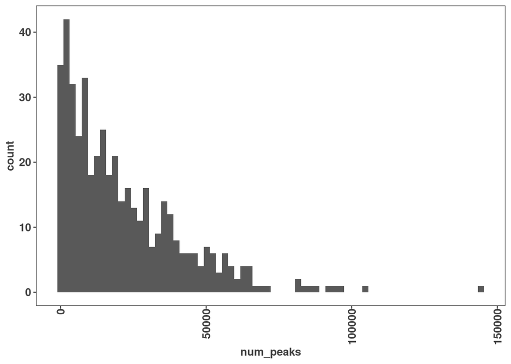

```r
num_peaks_df <- read_csv("analysis/results/num_peaks_df.csv")
# Distriubtion of peak numbers of all 460 DBPs
ggplot(num_peaks_df, aes(x = num_peaks)) +
  geom_histogram(bins = 70)
```

```r
summary(num_peaks_df$num_peaks)
```

```
##    Min. 1st Qu.  Median    Mean 3rd Qu.    Max.
##     261    5643   15736   21524   32053  144675
```

The median number of peaks is nearly 16,000, but most DBPs tend to have many fewer binding events. The distribution looks like an expotential decay. Surprisingly, one DBP has nearly 150,000 peaks.

# Plotting the total genome coverage of each DBPs ChIP peaks

Here we want to see the relationship between the number of peaks and amount of genome covered

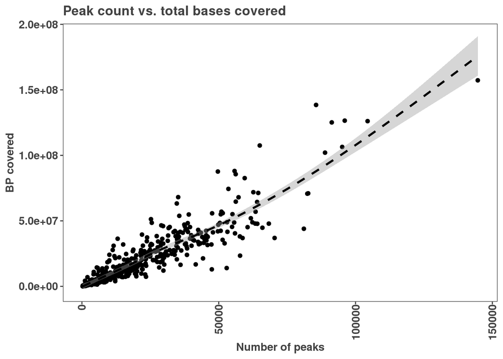

```r
# Plotting number of peaks versus total genome coverage
ggplot(num_peaks_df, aes(x = num_peaks, y = total_peak_length)) +
  geom_point() +
  geom_smooth(method = "gam", se = TRUE, color = "black", lty = 2)+

  ylab("BP covered") +
  xlab("Number of peaks") +
  ggtitle("Peak count vs. total bases covered")
```

```r
ggsave("analysis/figures/peak_num_vs_coverage.pdf")
```

We observe a somewhat linear relationship between peak number and genome coverage Thus, more peaks = more genome coverage. This could be interpreted as the peak sizes are typically uniform and thus linearly increase genome coverage

# Plotting number of peaks versus overlaps with promoters

Here we are comparing the number of peaks for a given DBP to the total number of promoters those peaks overlap

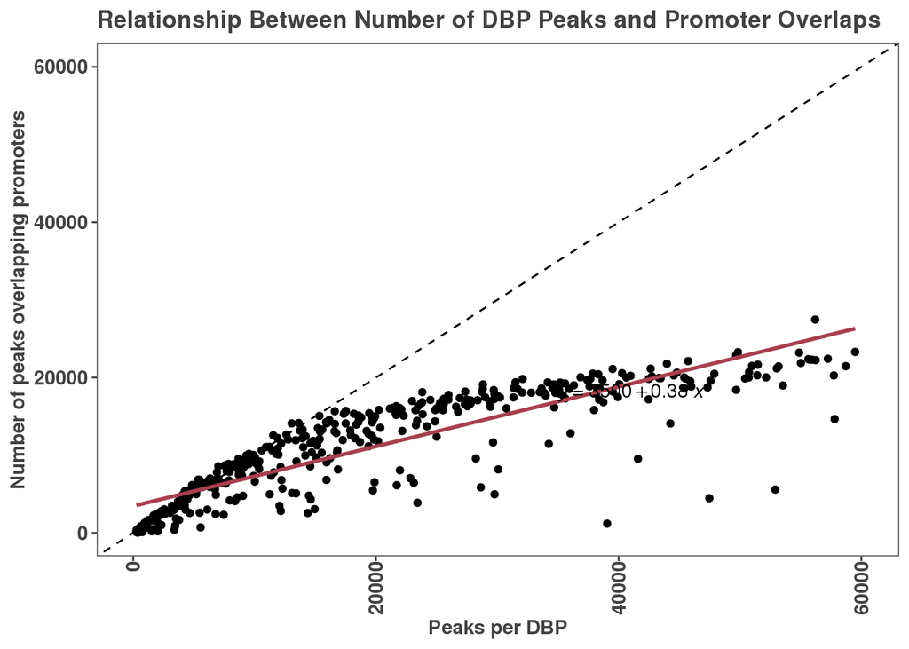

```r
# Plotting number of peaks versus peaks overlapping promoters
ggplot(num_peaks_df,
       aes(x = num_peaks, y = peaks_overlapping_promoters)) +
  xlab("Peaks per DBP") +
  ylab("Number of peaks overlapping promoters") +
  ggtitle("Relationship Between Number of DBP Peaks and Promoter Overlaps")+
  geom_point() +
  geom_abline(slope = 1, linetype="dashed") +
  geom_smooth(method = "lm", se=FALSE, formula = 'y ~ x',
              color = "#a8404c") +
  stat_regline_equation(label.x = 35000, label.y = 18000) +
  ylim(0,60100) +
  xlim(0,60100)
```

```r
ggsave("analysis/figures/3_peak_num_vs_promoter_coverage.pdf")
```

There is not a great linear fit across all the data. We observe that below 20,000 peaks there seems to be a linear relationship however as the peak number increases fewer promoters are overlapping. This suggests that after 20,000 peaks most promoters are covered and now the peaks are elsewhere.

# Peaks per DBP overlaps with genebody

Here we want to see how many of the peaks for each DBP overlap genebodys.

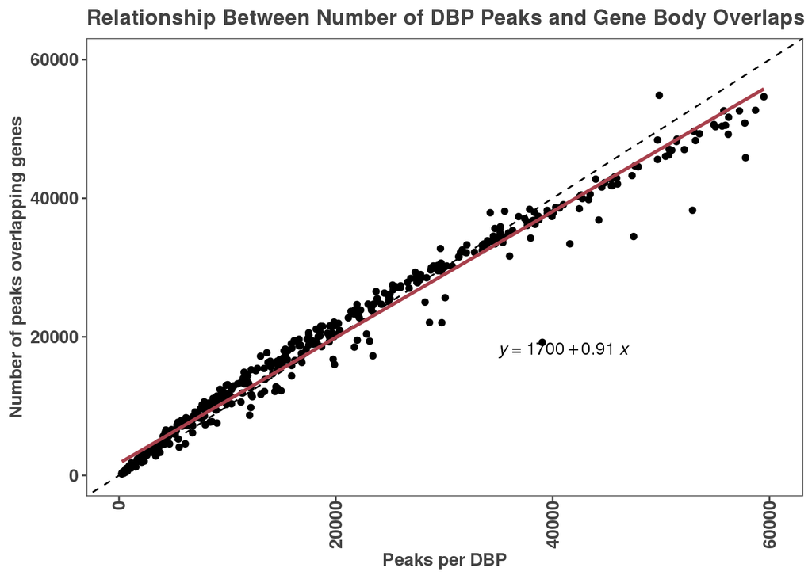

```r
# Plotting peak overlaps with genebody
ggplot(num_peaks_df,
       aes(x = num_peaks, y = peaks_overlapping_genebody)) +
  xlab("Peaks per DBP") +
  ylab("Number of peaks overlapping genes") +
  ggtitle("Relationship Between Number of DBP Peaks and Gene Body Overlaps")+
  geom_point() +
  geom_abline(slope = 1, linetype="dashed") +
  geom_smooth(method = "lm", se=F, formula = 'y ~ x',
              color = "#a8404c") +
  stat_regline_equation(label.x = 35000, label.y = 18000) +
  ylim(0,60100) +
  xlim(0,60100)
```

```r
ggsave("analysis/figures/4_peak_num_vs_gene_body_coverage.pdf")
```

We observe that there is a very linear relationship between peak number and genebody overlap. This means that the more peaks you have the more likely you are to overlap a genebody. One way to think about this is that genebody overlaps explains most of the peaks – or most peaks overlap genebodys. We would expect dots (DBPs) that are below the line are binding outside genebodys.

However, one artifact could be if genebodys take up most of the genome this would also make a linear trend.

# Determing how much of the genome is comprised of genebodies.

```r
# there is a large amount of data explained (almost all by genebodys)
# Let's see what percentage of the genome genebodys cover:
reduced_gene_bodies <- gencode_gr[gencode_gr$type == "gene"] %>%
  GenomicRanges::reduce() %>%
  width() %>%
  sum()

# percentage of gene bodies in genome
reduced_gene_bodies/3.2e9
```

```
## [1] 0.589159
```

So we observe that genebodys do cover a lot of the genome. Since they represent a majority of the genome we would expect a linear relationship. Nonetheless we conclude that most peaks overlap genebodys.

# Counting the number of overlaps at each promoter

promoters are the cols and DBPs rows thus we can retrieve the number of binding events at each promoter unlike the “counts parameter” that just gives total number of overlaps

```r
# Creating matrix of promoters(annotation feature) as cols and DBPs as rows (takes ~5min)
promoter_peak_occurence <- count_peaks_per_feature(lncrna_mrna_promoters, filtered_consensus_peaks,
                                               type = "occurrence")

# test to make sure everything is in right order
stopifnot(all(colnames(promoter_peak_occurence) == lncrna_mrna_promoters$gene_id))

# Formatting final data.frame from peak occurence matrix
peak_occurence_df <- data.frame("gene_id" = colnames(promoter_peak_occurence),
                                "gene_name" = lncrna_mrna_promoters$gene_name,
                                "gene_type" = lncrna_mrna_promoters$gene_type,
                                "chr" = lncrna_mrna_promoters@seqnames,
                                "1.5_kb_up_tss_start" = lncrna_mrna_promoters@ranges@start,
                                "strand" = lncrna_mrna_promoters@strand,
                                "number_of_dbp" = colSums(promoter_peak_occurence))
# exporting
write_csv(peak_occurence_df, "analysis/results/peak_occurence_dataframe.csv")
```

# Plotting

Here we are going to plot the distribution of the number of DBPs on a given promoter

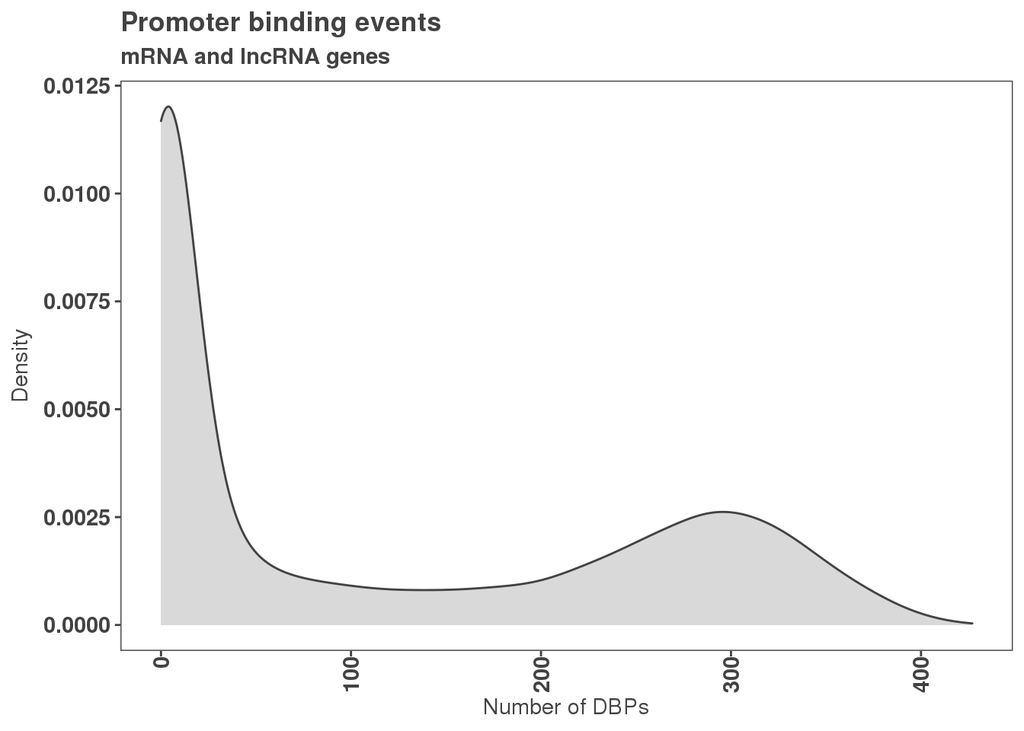

```r
ggplot(peak_occurence_df, aes(x = number_of_dbp)) +
geom_density(alpha = 0.2, color = "#424242", fill = "#424242") +

  theme_paperwhite() +
  xlab(expression("Number of DBPs")) +
  ylab(expression("Density")) +
  ggtitle("Promoter binding events",
          subtitle = "mRNA and lncRNA genes")
```

```r
ggsave("analysis/figures/num_binding_events_per_promoter.pdf")
```

!COOL Result – maybe ! We observe a bimodal distribution of binding at promoters. This indicates that there are two types of promoters: 1) Those that have up to 70 or so DBPs bound 2) High binders that have more than 200 DBPs We note a lag betweent 100-200 DBPs per promoter. This could indicate that this is not a preferable number of DBPs.

# Multiple promoter window sizes

Let’s iterate over promoter window sizes and see if this effect is maintained. First we’ll generate promoter windows of multiple

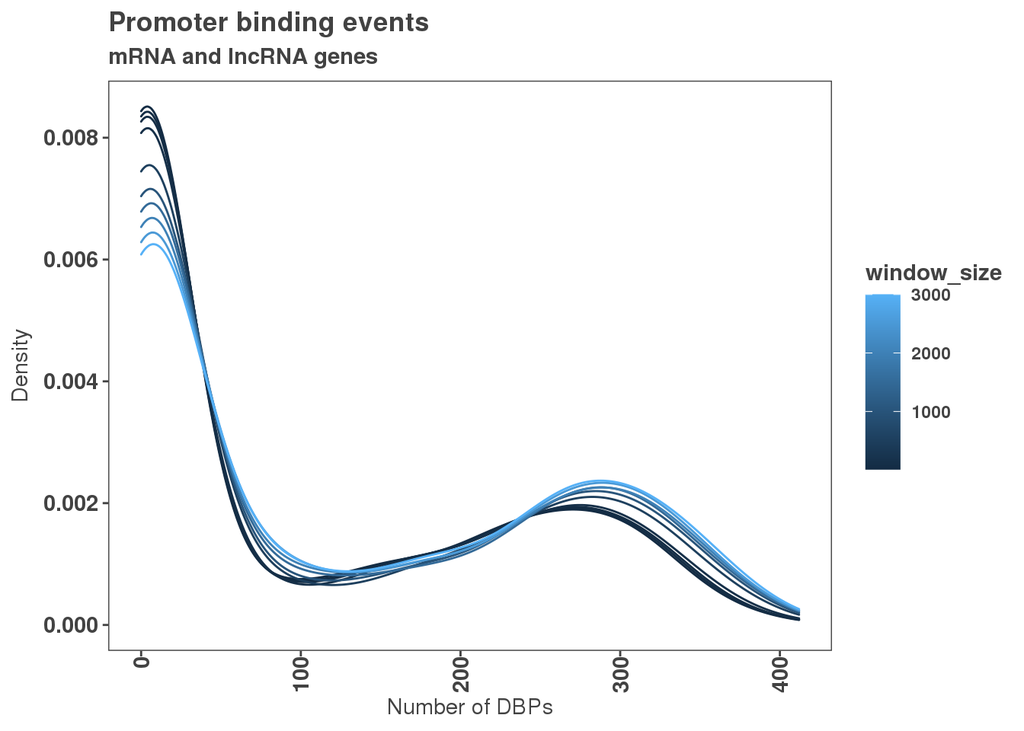

```r
# Window sizes we want to iterate over.
window_size <- c(10, 30, 50, 100, 500, 1000, 1500, 2000, 2500, 3000)

# To test this function quickly, we'll subset gencode to a sampling of genes
gene_samples <- gencode_gr[gencode_gr$type == "gene"]
gene_samples <- gene_samples[gene_samples$gene_type %in% c("lncRNA", "protein_coding")]
gene_samples <- gene_samples[sample(1:length(gene_samples), 1000)]

promoter_list <- lapply(window_size, function(x) {
  GenomicRanges::promoters(gene_samples, upstream = x, downstream = x)
})
names(promoter_list) <- window_size

peaks_per_feature_list <- lapply(promoter_list, function(x) {
  count_peaks_per_feature(x, filtered_consensus_peaks, type = "occurrence")
})

num_dbp_list <- lapply(peaks_per_feature_list, function(x) {
  colSums(x)
})


for(i in 1:length(window_size)) {
  num_dbp_list[[i]] <- data.frame("gene_id" = names(num_dbp_list[[i]]),
                                  "num_dbp" = num_dbp_list[[i]],
                                  "window_size" = window_size[[i]])
}

num_dbp_df <- bind_rows(num_dbp_list)


ggplot(num_dbp_df, aes(x = num_dbp, color = window_size, group = window_size)) +
geom_density(alpha = 0.2) +
  theme_paperwhite() +
  xlab(expression("Number of DBPs")) +
  ylab(expression("Density")) +
  ggtitle("Promoter binding events",
          subtitle = "mRNA and lncRNA genes")
```

Awesome, we see that window size is not affecting the bimodal distribution. So this is an intersting result that no matter the window size we find tow populations of promoters: “normal” and high affinity promoters.

# Binding properties versus total RNA expression.

Let’s take a look at HEPG2 RNAseq downloaded from ENCODE. We will start by loading in that data and then looking at the distribution of gene expression and where to filter.

```r
salmon_tpm <- read.csv("/scratch/Shares/rinnclass/CLASS_2022/JR/CLASS_2022/class_exeRcises/analysis/18_running_RNAseq_NF_CORE/preclass_NF_core_RUN/results/salmon/salmon_merged_gene_tpm.csv")

samplesheet <- read_rds("/scratch/Shares/rinnclass/CLASS_2022/JR/CLASS_2022/class_exeRcises/analysis/19_rnaseq/final_samplesheet.rds")

g2s <- read_csv("/scratch/Shares/rinnclass/CLASS_2022/JR/CLASS_2022/class_exeRcises/analysis/18_running_RNAseq_NF_CORE/g2s.csv") %>%
  dplyr::select(gene_id, gene_name)
```

# Organizing the loaded data into a nice data frame of TPM values.

```r
# First we will take the mean TPM between replicates for total RNA (Homo_sapiens_hepg2).

tpm <- salmon_tpm %>%
  pivot_longer(cols = 2:ncol(.), names_to = "sample_id", values_to = "tpm") %>%
  merge(samplesheet) %>%
  group_by(gene_id, condition) %>%
  summarize(tpm = mean(tpm, na.rm = T)) %>%
  filter(condition == "homo_sapiens_hepg2") %>%
  merge(g2s)

# Let's look at how many DBPs have a matching gene symbol in the gene expression dataset.
dbp_names <- tolower(num_peaks_df$dbp)
table(dbp_names %in% tolower(tpm$gene_name))
```

```
##
## FALSE  TRUE
##    14   446
```

```r
dbp_names[!(dbp_names %in% tolower(tpm$gene_name))]
```

```
##  [1] "h3k27ac"         "h3k36me3"        "h3k4me1"         "h3k4me2"
##  [5] "h3k4me3"         "h3k9ac"          "h3k9me3"         "h4k20me1"
##  [9] "kiaa2018"        "polr2aphosphos2" "polr2aphosphos5" "zcchc11"
## [13] "znf788"          "zzz3"
```

```r
# There are 14 missing. It looks like it's mostly the histone modifactions -- which are not genes.

dbp_expression <- tpm %>% filter(tolower(gene_name) %in% dbp_names) %>%
  mutate(gene_name = tolower(gene_name))

# Final set of DBPs we can use between ENCODE names and TPM names from Salmon
# Making a data frame of DBPs we can use and TPM and overlaps
dbp_expression_vs_peak_number <- dbp_expression %>%
  left_join(num_peaks_df %>% dplyr::rename(gene_name = dbp) %>%
              mutate(gene_name = tolower(gene_name)))
```

# As a first check of the data let’s see how TPM relates to number of peaks

A resonalble hypothesis is that higher abundant proteins may have more peaks.

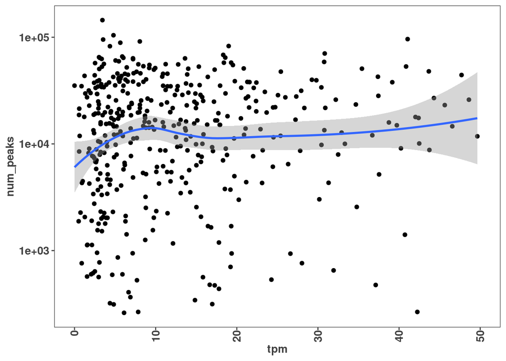

```r
ggplot(dbp_expression_vs_peak_number, aes(x = tpm, y = num_peaks)) +
  geom_point() +
  scale_y_log10() +
  xlim(0,50) +
  geom_smooth()
```

It seems that there’s no correlation between the expression level of the gene and the number of peaks bound by the resulting protein. This makes sense due to the fact that mRNA levels and protein levels are only weakly correlated.

# Loading in peak occurence DF we made above.

This data frame has all our peak info per DBP and we will merge TPM data and other features. This way we have all the inforamtion we need for each promoter (rows)

```r
# Loading in promoter peak occurence DF we made above (as matrix and converted to datframe)
# Around line 330
promoter_features_df <- read.csv("/scratch/Shares/rinnclass/CLASS_2022/JR/CLASS_2022/class_exeRcises/analysis/12_peak_features/peak_occurence_dataframe.csv")

# Merging int TPM values.
promoter_features_df <- promoter_features_df %>%
  left_join(tpm)
```

# Plotting number of DBPs (TFs) bound to a promoter versus expression of that promoter.

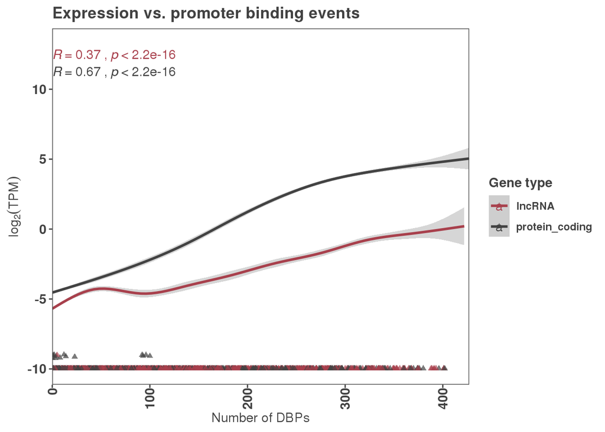

```r
ggplot(promoter_features_df,
            aes(y = log2(tpm + 0.001), x = number_of_dbp, color = gene_type)) +
geom_point(data = promoter_features_df %>% filter(tpm < 0.001),
             shape = 17, alpha = 0.7) +
  geom_smooth(method = 'gam', formula = y ~ s(x, bs = "cs")) +
  stat_cor() +
  scale_x_continuous(expand = c(0,0)) +
  scale_color_manual(values = c("#a8404c", "#424242"), name = "Gene type") +
  ggtitle("Expression vs. promoter binding events") +
  xlab(expression('Number of DBPs')) +
  ylab(expression(log[2](TPM)))
```

```r
ggsave("analysis/figures/binding_versus_expression_all.pdf")
```

We find two patterns of promoter binding versus expression: 1) Expression is linear with respect to number of binding events This is similar to what has been published by Mele et al. Genome Research 2) There is a population of promoters that are NOT expresed across the range of bound DBPs

# Filtering by expression value.

We saw abov that although there is a linear trend the expression values are very low at promoters with less than 100 DBPs bound. Somewhere around TPM of 0.04 which is very low!

Let’s look at the distribution of expression values to determine where to filter. It seems common to filter as “expressed” if there is at least one TPM.

# Plotting distribution of TPMS

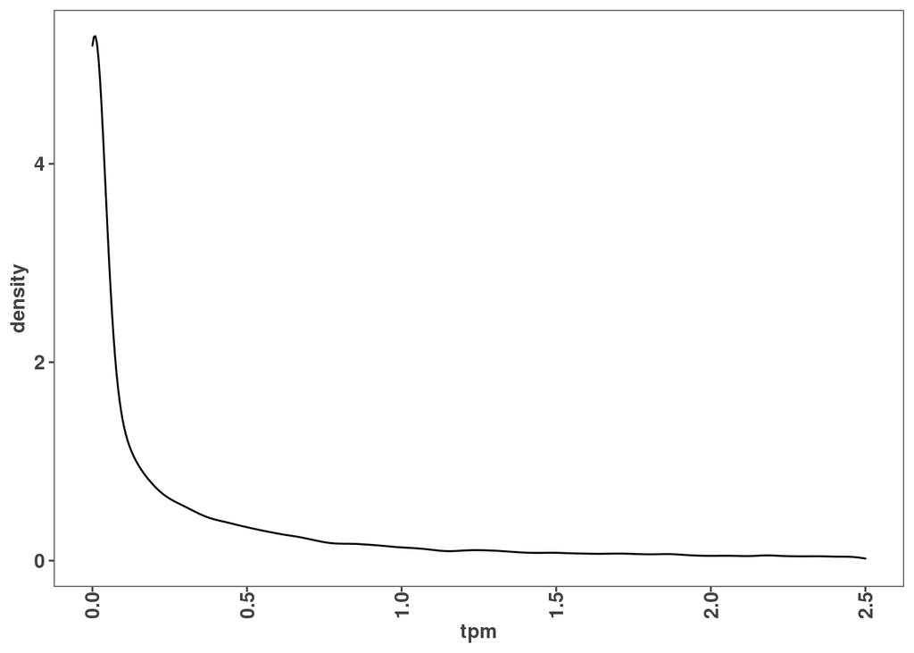

```r
ggplot(promoter_features_df, aes(x = tpm)) +
  geom_density() +
  xlim(0,2.5)
```

We see that most genes have very low expression and we see an inflection point in the density plot at around 0.25 TPM. Therefore, we’ll call any gene with > 0.25 TPM as expressed.

# Filtering to “expressed genes” > 0.25 TPM

We will add this to promoter_features_df.

```r
# making "expressed" col by filtering > .25
promoter_features_df <- promoter_features_df %>%
  mutate(expressed = tpm > 0.25)
table(promoter_features_df$expressed)
```

```
##
## FALSE  TRUE
## 17162 19550
```

If we make this cutoff, 19,550 genes are expressed. This is somewhat typical ~50% of genes.

# Plotting number of expressed and not expressed genes

```r
ggplot(promoter_features_df %>% filter(!is.na(tpm)), aes(x = expressed)) +
  geom_bar() +
  geom_text(stat='count', aes(label=..count..), vjust=-1)
```

[output not shown]

# Binding versus expression of “expressed” genes

Let’s look at the relationship between the number of TFs on a promoter and the expression only for expressed genes.

```r
ggplot(promoter_features_df %>% filter(expressed == TRUE),
            aes(y = log2(tpm), x = number_of_dbp, color = gene_type)) +
  geom_bin_2d() +
  geom_smooth(method = 'gam', formula = y ~ s(x, bs = "cs")) +
  stat_cor()
```

[output not shown]

Suprisingly, there are genes which have no DBPs bound in this dataset, but are still expressed. What are the gene types of these genes? Are they transcribed by a different polymerase? Perhaps this highlights the fact that although we have a large number of DBPs in this dataset, there are still many other transcription factors not profiled. We have approximately 1/3 of the total identified human TFs (460/1200).

# Determining Reservoirs

We previously published a phenomena of promoters bound by many DBPs but Do not follow the linear increase in expression at these promoters. We will now do this for HEPG2 cells by determining:

Those promtoers with high binding (second mode) and lack expression TPM < 0.001

```r
# reservoir defines as:
# greater than 100 DBPs bound at promoter
# less than 0.001 Tpm

promoter_features_df$hepg2_reservoir <-
  as.numeric(promoter_features_df$number_of_dbp > 100 &
               promoter_features_df$tpm < 0.001)
```

# merging in k562 reservoir informaiton

```r
# reading in file defining k562 reservoir
k562_df <- read_csv("/scratch/Shares/rinnclass/CLASS_2022/data/2020_k562_promoter_peak_df.csv")

# organizing data frame
k562_df <- k562_df %>%
  dplyr::select(gene_id, reservoir, conservative_reservoir, tpm, expression, tf_binding, promoter_mean_tpm, promoter_median_tpm, promoter_max_tpm) %>%
  dplyr::rename(k562_reservoir = reservoir,
                k562_conservative_reservoir = conservative_reservoir,
                k562_expression = expression,
                k562_tpm = tpm,
                k562_tf_binding = tf_binding,
                k562_promoter_mean_tpm =  promoter_mean_tpm,
                k562_promoter_median_tpm = promoter_median_tpm,
                k562_promoter_median_tpm = promoter_median_tpm,
                k562_promoter_max_tpm = promoter_max_tpm)

# Hepg2_DF
hepg2_df <- promoter_features_df %>%
  dplyr::select(gene_id, gene_name, tpm, number_of_dbp, hepg2_reservoir) %>%
   dplyr::rename( hepg2_tpm = tpm)

# merging data frames
hepg2_k562_promoter_features_df <- merge(hepg2_df, k562_df)

# summarizing overlaps
res_status <- hepg2_k562_promoter_features_df %>%
  group_by(hepg2_reservoir, k562_reservoir, k562_conservative_reservoir) %>%
  summarize(count = n())
```

# Defining high binder promoters

```r
# look at distribution of binding events
summary(promoter_features_df$number_of_dbp)
```

```
##    Min. 1st Qu.  Median    Mean 3rd Qu.    Max.
##     0.0     2.0    46.0   123.7   263.0   427.0
```

```r
# based on this deifining > 230 as high, 11-229 as medium and 10 or less as low
promoter_features_df <- promoter_features_df %>%
  mutate(binding_status = ifelse(number_of_dbp > 230, "high",
                                 ifelse(number_of_dbp < 10, "low", "medium")),
         expression_level = ifelse(tpm > 100, "high", ifelse(tpm > 0.25, "medium", "low")))
promoter_features_df$binding_status <- factor(promoter_features_df$binding_status,
                                              levels = c("low", "medium", "high"))
```

# High, medium and low binding promoters expression level

We will determine those genes that are expressed as > 0.25 TPM per above. Then plot the binding status of the promoters accordingly.

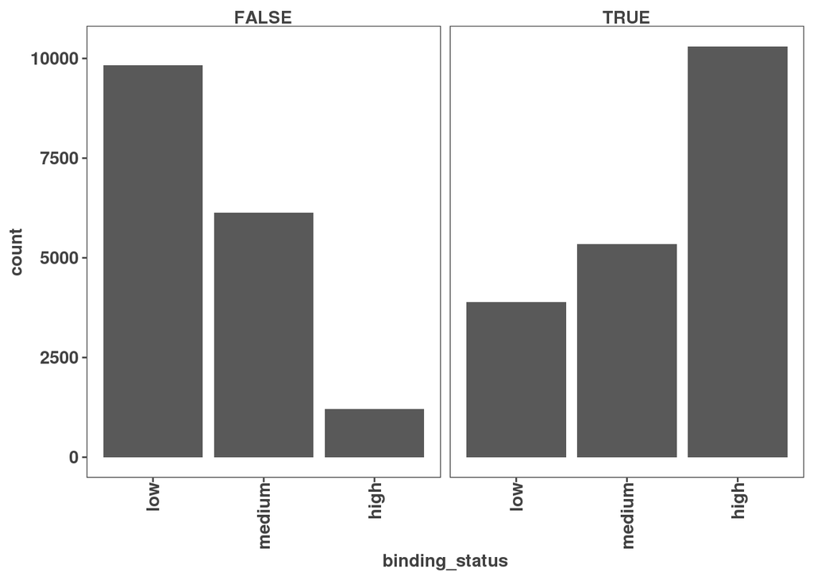

```r
ggplot(promoter_features_df %>% filter(!is.na(expressed)), aes(x = binding_status)) +
  geom_bar() +
facet_wrap(~expressed)
```

```r
# number of expressed in each binding category
table(promoter_features_df$binding_status)
```

```
##
##    low medium   high
##  13831  11477  11506
```

# Subsecting promoter peak occurence by high and low binding promoters from above.

```r
# promoters with more than 230 DBPs from peak occurence matrix
high_binding_promoters <- promoter_peak_occurence[,promoter_features_df %>%
                                                    filter(binding_status == "high") %>%
                                                    pull(gene_id)]

# promoters with less than 10 DBPs from peak occurence matrix
low_binding_promoters <- promoter_peak_occurence[,promoter_features_df %>%
                                                    filter(binding_status == "low") %>%
                                                    pull(gene_id)]

# percentage (occupancy) of promoters bound by each DBP
high_binding_occupancy <- rowSums(high_binding_promoters) / ncol(high_binding_promoters)

low_binding_occupancy <- rowSums(low_binding_promoters) / ncol(low_binding_promoters)

# combining into data.frame
binding_occupancy <- data.frame(dbp = names(high_binding_occupancy),
                                high = high_binding_occupancy,
                                low = low_binding_occupancy) %>%
  # ratio of occupancy on high versus low binding promoters
  mutate(high_vs_low_ratio = log2((high + 0.001) / (low + 0.001)))
```

# PLotting density of occupancy of DBPs on high and low binding promoters

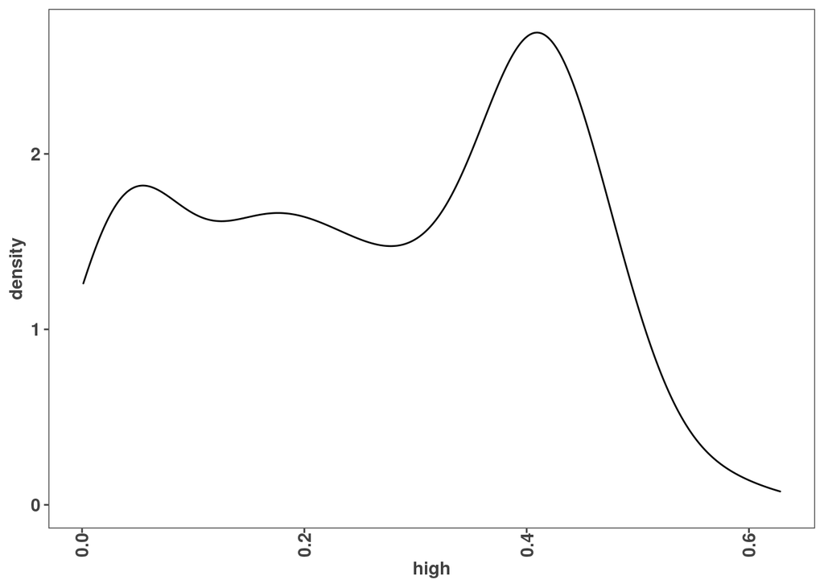

```r
# Density of DBPs occupancy on high binders
ggplot(binding_occupancy, aes(x = high)) +
  geom_density()
```

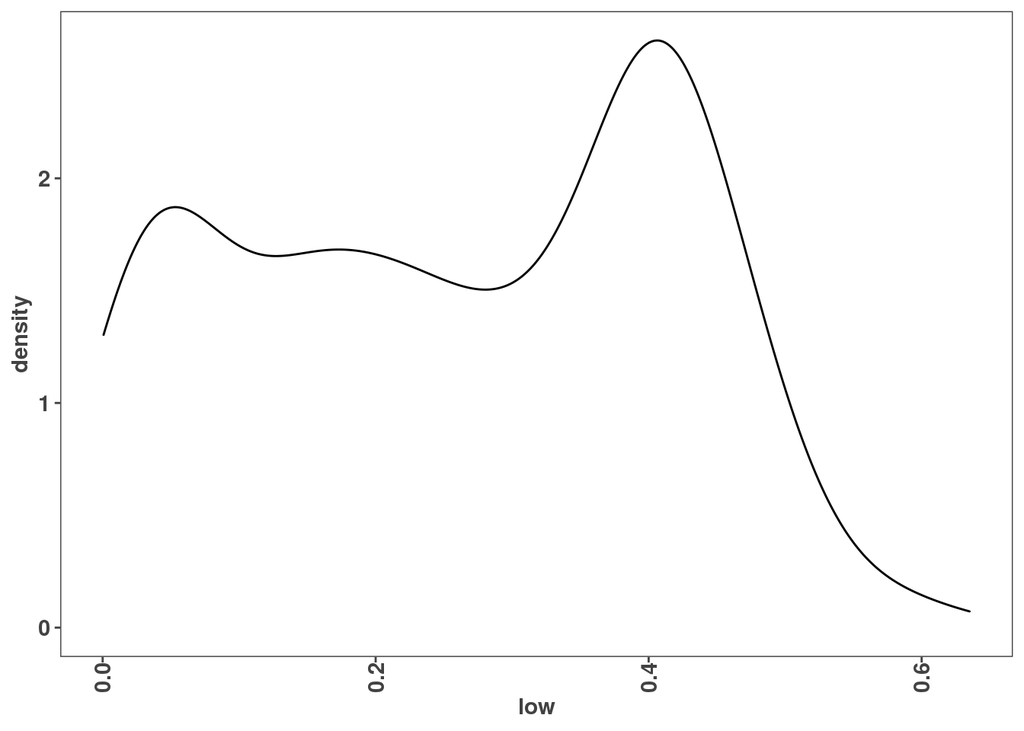

```r
# Density of DBPs occupancy on low binders
ggplot(binding_occupancy, aes(x = low)) +
  geom_density()
```

# Are there some DBPs that seperate the expressed vs not expressed high binding promoters?

This analysis will point us towards a possible repressor of high binding promoters that results in lower expression despite high binding.

```r
# subsecting promter_features to highly expressed and high binding status
high_binders <- promoter_features_df %>%
  filter(binding_status == "high")

# DBPs on high binders (hb)  and highly expressed
expressed_hb <- promoter_peak_occurence[,high_binders %>%
                                                    filter(expression_level == "high") %>%
                                                    pull(gene_id)]

# DBPs on highbinders (hb) that are lowly expressed
lowly_expressed_hb <- promoter_peak_occurence[,high_binders %>%
                                                    filter(expression_level == "low") %>%
                                                    pull(gene_id)]

# Percentage of DBP representation on expressed versus lowly expressed high binding promters
ehb_occupancy <- rowSums(expressed_hb) / ncol(expressed_hb)
lhb_occupancy <- rowSums(lowly_expressed_hb) / ncol(lowly_expressed_hb)
hb_binding_occupancy <- data.frame(dbp = names(ehb_occupancy),
                                high_exp = ehb_occupancy,
                                low_exp = lhb_occupancy ) %>%
  mutate(high_vs_low_ratio = log2((high_exp + 0.001) / (low_exp + 0.001)))
```

# Plotting DBP occupance on expressed versus lowly expressed high binding promoters

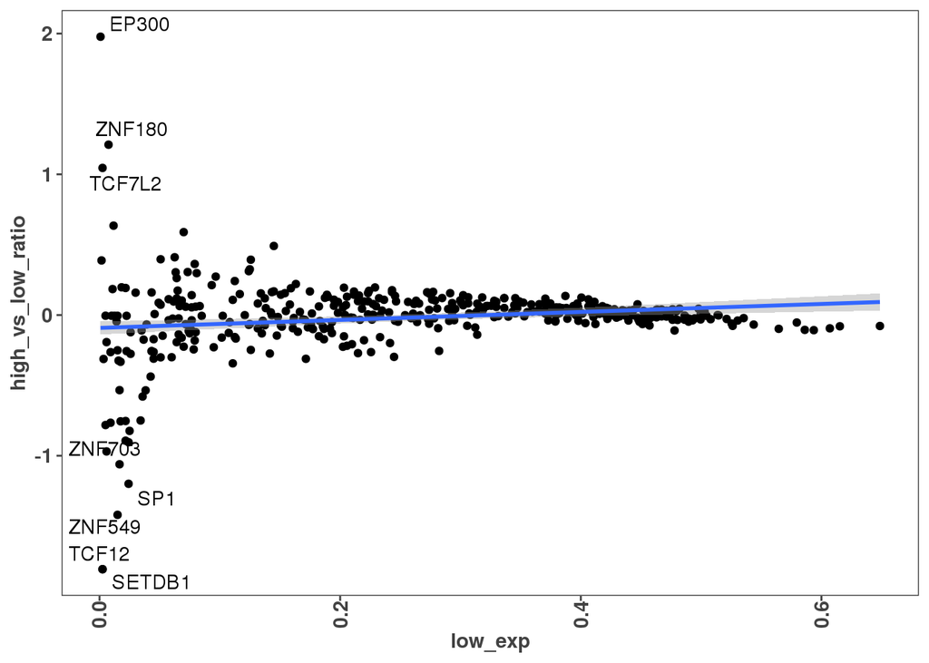

```r
library(ggrepel)

ggplot(hb_binding_occupancy, aes(x = low_exp, y = high_vs_low_ratio, label = dbp)) +
  geom_point() +
  geom_text_repel(data = hb_binding_occupancy %>% filter(high_vs_low_ratio < -1)) +
  geom_text_repel(data = hb_binding_occupancy %>% filter(high_vs_low_ratio > 0.75)) +
  geom_smooth(method = "lm")
```

# Testing for the discriminators for the polII positive promoters.

Based on the results above we hypothesize that Pol II would be a good indicator of expression versus non expressed high binders.

```r
polII_names <- rownames(promoter_peak_occurence)[grep("POLR", rownames(promoter_peak_occurence))]

# Let's add a column with PolII status to our data.frame
polII_counts <- colSums(promoter_peak_occurence[polII_names,])
polII_counts_df <- data.frame(gene_id = names(polII_counts),
                              polII_status = polII_counts)
polII_counts_df <- polII_counts_df[promoter_features_df$gene_id,]
promoter_features_df$polII_status <- polII_counts_df$polII_status

# Defining high binding
high_binders <- promoter_features_df %>%
  filter(binding_status == "high")
```

```r
# at least one Pol II bound high binder and highly expressed and Pol II low expressed
expressed_hb <- promoter_peak_occurence[,high_binders %>%
                                                    filter(expression_level == "high", polII_status > 1) %>%
                                                    pull(gene_id)]
lowly_expressed_hb <- promoter_peak_occurence[,high_binders %>%
                                                    filter(expression_level == "low", polII_status > 1) %>%
                                                    pull(gene_id)]

# percentage of promoters with Pol II and expressed high binders
ehb_occupancy <- rowSums(expressed_hb) / ncol(expressed_hb)

# percentage of promoters with Pol II and lowly expressed high binders
lhb_occupancy <- rowSums(lowly_expressed_hb) / ncol(lowly_expressed_hb)

hb_binding_occupancy <- data.frame(dbp = names(ehb_occupancy),
                                high_exp = ehb_occupancy,
                                low_exp = lhb_occupancy ) %>%
  mutate(high_vs_low_ratio = log2((high_exp + 0.001) / (low_exp + 0.001)))
library(ggrepel)
```

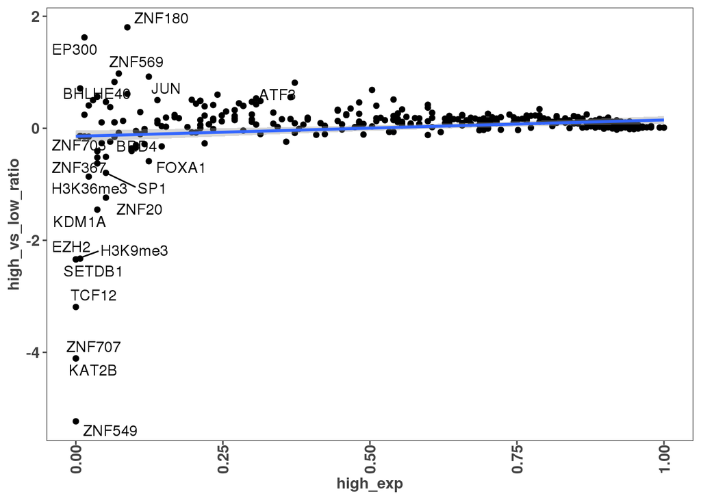

```r
ggplot(hb_binding_occupancy, aes(x = high_exp, y = high_vs_low_ratio, label = dbp)) +
  geom_point() +
  geom_text_repel(data = hb_binding_occupancy %>% filter(high_vs_low_ratio < -0.5)) +
  geom_text_repel(data = hb_binding_occupancy %>% filter(high_vs_low_ratio > 0.75)) +
  geom_smooth(method = "lm")
```

# How many genes are expressed but don’t have any DBPs bound

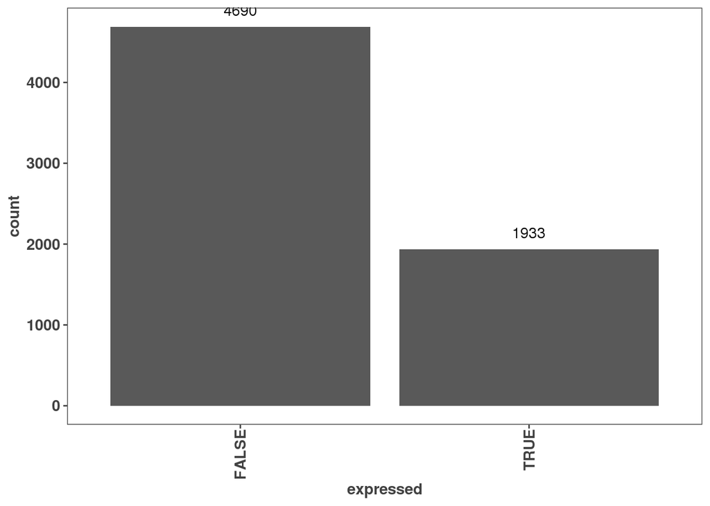

```r
ggplot(promoter_features_df %>%
         filter(number_of_dbp == 0, !is.na(tpm)), aes(x = expressed)) +
          geom_bar() +
          geom_text(stat='count', aes(label=..count..), vjust=-1)
```

This is probably explained that there is a different TSS that is bound – we are using the longest isoform, but this may not be the one that is active in this data. A better approach would be to do this on an isoform level.

## ATAC-seq

Let’s look to see if there are differences in the number of ATAC-seq peaks over the promoters with different amounts of DBPs.

```r
# Download data:
# wget https://www.encodeproject.org/files/ENCFF536RJV/@@download/ENCFF536RJV.bed.gz

# Converting downloaded data to "bed" format via read.table
atac_peaks <- read.table("data/ENCFF536RJV.bed.gz",
                         col.names = c("chrom", "start", "end", "name", "score",
                                       "strand", "signal_value", "pval",
                                       "qval", "summit"))

# Crateing GRanges of ATAC peaks
atac_peaks_gr <- GRanges(seqnames = atac_peaks$chrom,
                         ranges = IRanges(start = atac_peaks$start,
                                          end = atac_peaks$end))
atac_peaks_list <- list(atac_peaks_gr)
names(atac_peaks_list) <- "atac"

# ATAC peaks that overlap with promoters
atac_promoter_ov <- count_peaks_per_feature(lncrna_mrna_promoters, atac_peaks_list, type = "counts")
atac_promoter_df <- atac_promoter_ov %>%
  t() %>%
  as.data.frame() %>%
  rownames_to_column("gene_id")
```

# Plotting the distribution of ATAC peaks overlapping promoters.

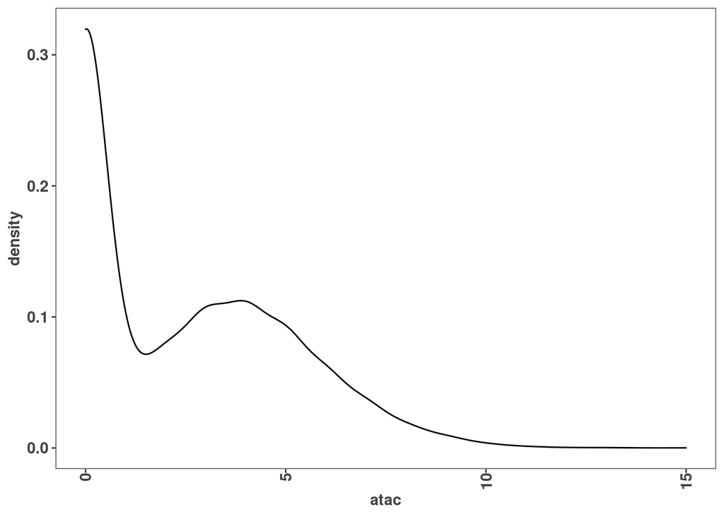

```r
ggplot(atac_promoter_df, aes(x = atac)) +
  geom_density(adjust = 1.9)
```

We observe that there is a distribution of 1 or less and another peak around 5 ATAC peaks overlapping a promoter.

```r
promoter_features_df <- promoter_features_df %>%
  left_join(atac_promoter_df)
```

# Plotting ATAC peak overlaps versus number of DBPS bound

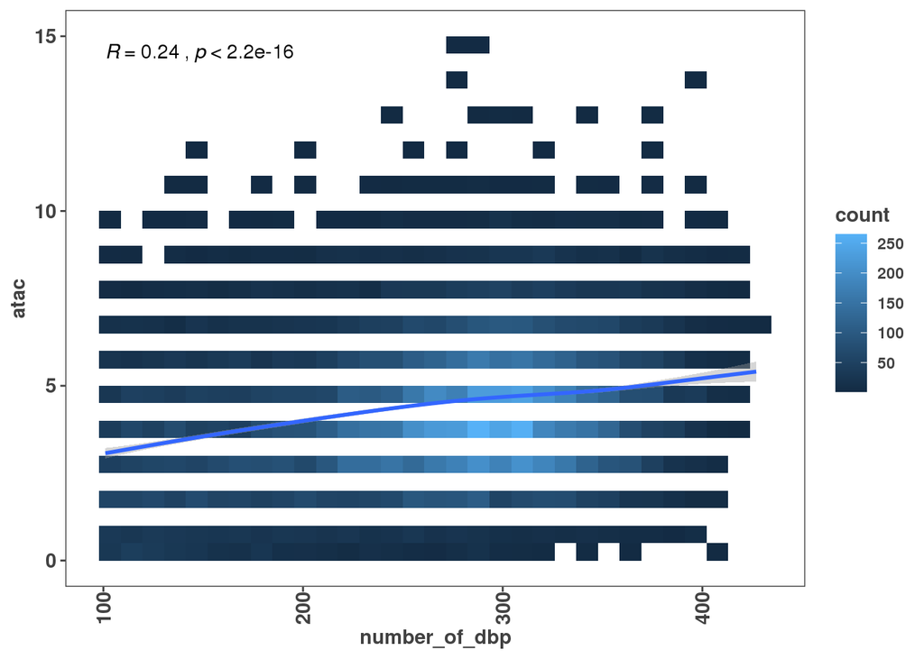

```r
ggplot(promoter_features_df %>% filter(number_of_dbp > 100), aes(x = number_of_dbp, y = atac)) +
  geom_bin_2d() +
  geom_smooth() +
  stat_cor()
```

# writting out useful files made above to results

```r
write_csv(promoter_features_df, "analysis/results/tables/promoter_features_df.csv")
write_csv(tpm, "analysis/results/tables/mean_tpm_per_condition.csv")
write_csv(samplesheet, "analysis/results/tables/samplesheet.csv")
write_csv2(res_status, "analysis/results/tables/reservoir_overlap_stats.csv")
write_csv2(hepg2_k562_promoter_features_df, "analysis/results/tables/hepg2_k562_promoter_features_df.csv")
```